# `dvs`: version your data files next to your code

Analysis projects pair code with data, and git is only good at half of that pairing. dvs keeps the data in the project tree, moves the bytes to shared storage, and gives git a few hundred bytes of metadata per file to track instead.

## Four verbs, two surfaces

Everything below is a real capture of dvs 0.4.0 running against a project with PK datasets. The same four verbs are available as a CLI and as an R package, and both operate on the same project interchangeably.

**init**point the project at a shared storage directory

**add**hash, compress, and store files; write metadata

**status**compare every tracked file against its metadata

**get**materialize missing files from storage, hash-verified

## The loop

### 1. Initialize once per project

`dvs init` writes `dvs.toml`, the entire project configuration. It belongs in git; every clone reads the storage location from it.

```
$ dvs init /tmp/nfs-share/dvs-storageDVS Initialized at "/private/tmp/projects/pkpd-study"$ cat dvs.tomlcompression = "zstd"[backend]path = "/private/tmp/nfs-share/dvs-storage"group = "staff"
```

### 2. Add data with a message

Each file is hashed (blake3), compressed (zstd), and stored once per unique content. Note the sizes: a 2.9 KB file stores as 842 B. The message travels with the data, like a commit message for a dataset.

[output not shown]

### 3. Status knows three states

`current` matches the metadata, `unsynced` is on disk but modified, and `absent` is tracked but not on disk, the state every fresh clone starts in.

[output not shown]

### 4. Get restores the rest

Retrieval is verified against the recorded hash before the file is moved into place; a re-add brings a modified file back to `current`.

[output not shown]

## What git tracks, what storage holds

#### In git

`dvs.toml`, one small JSON meta file per data file under `.dvs/`, and the `.gitignore` entries dvs wrote. A complete, versioned description of the data at kilobyte scale.

#### In storage

Content-addressed blobs, named by their hash, compressed, read-only, deduplicated across every project and user that shares the storage. Plus an append-only audit log of who added what, when.

The proof, from the session above: the meta file records the hash, git stages only metadata (no CSV in sight), and the blob sits in storage under its hash at a third of the original size:

[output not shown]

## The same story from R

The R package returns tibbles, so status and results plug straight into dplyr pipelines. This is a live console transcript:

[output not shown]

## Slide-ready captures

High-resolution PNG renders of the frames above, ready to drop into a deck. Right-click any image to save it (the same files live in the repo under `screenshots/`).

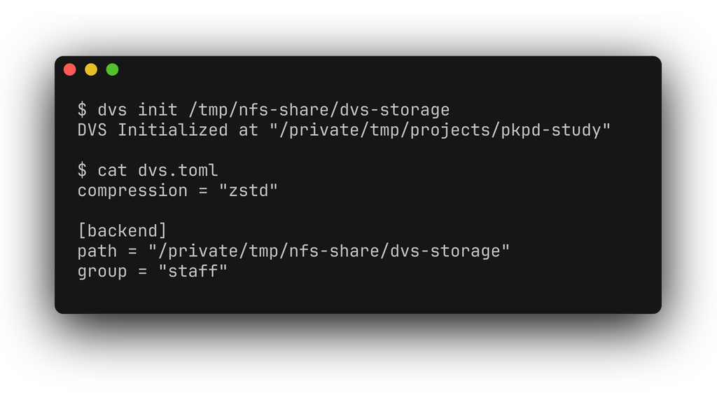

init: point the project at shared storageright-click the image to save it as dvs-cli-01-init.png

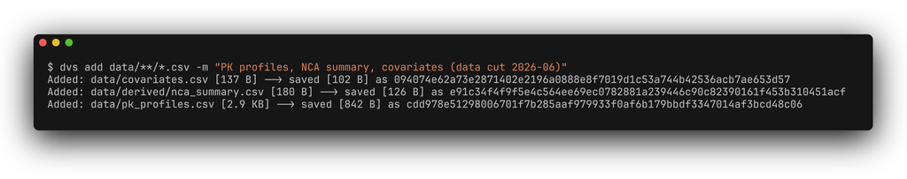

add: hash, compress, store, and record a messageright-click the image to save it as dvs-cli-02-add.png

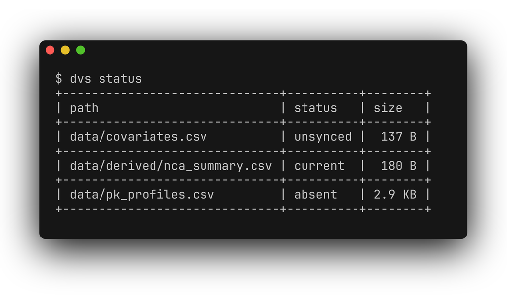

status: current, unsynced, and absent at a glanceright-click the image to save it as dvs-cli-03-status-states.png

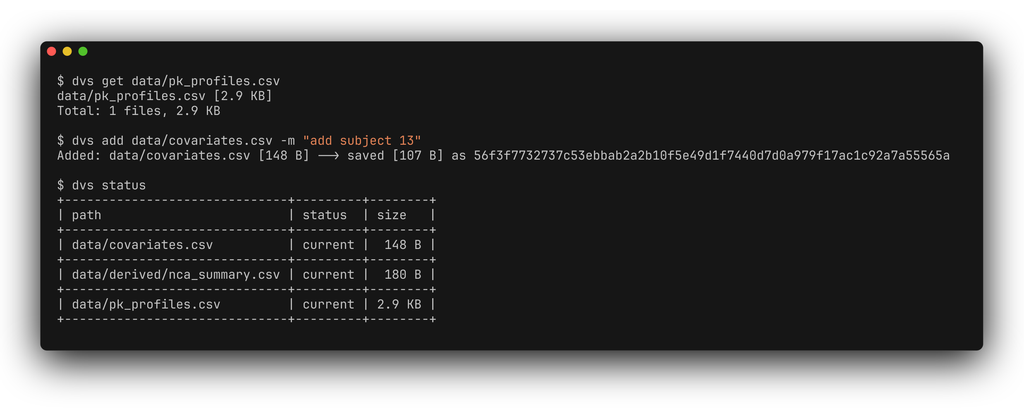

get: restore files from storage, verified by hashright-click the image to save it as dvs-cli-04-get.png

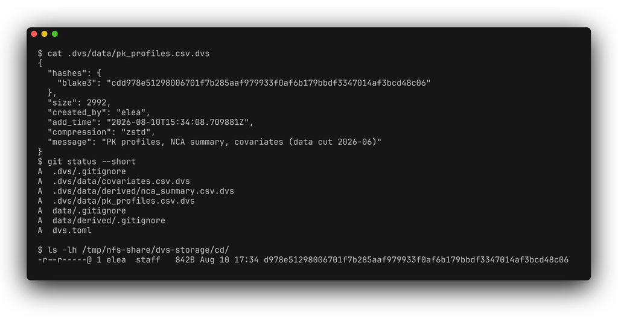

what git tracks vs what storage holdsright-click the image to save it as dvs-git-metadata-vs-blob.png

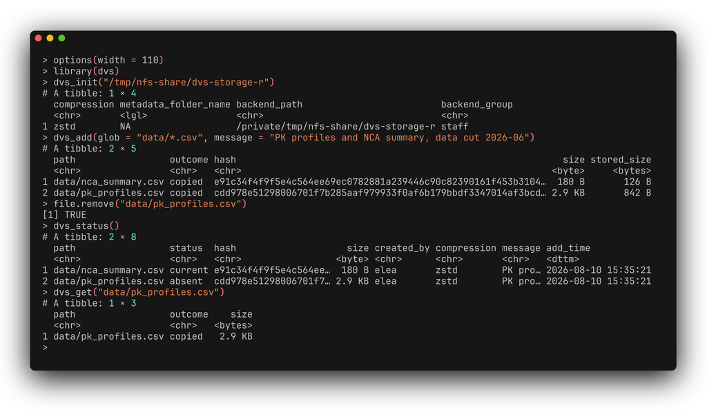

the same four verbs from an R sessionright-click the image to save it as dvs-r-session.png